# Python_Term_Project_Final

### **Term-Project**

*Author*: Aybike Dilek

*Date*: 31.01.2021

**Project Definition & Introduction**

The term project aimed to conduct various exploratory analyses and to provide basic inferential analyses using House Sales in King County, USA dataset.

The main motivation of this project was exploring the feature of the sold houses in King Country, USA such as price, sqft_living, area and, creating a basic linear regression model to predict the price of the house base on its feature such as sqft_living.

**About Dataset**

The dataset contains the various data points for sold houses in King County, USA from **2014-05** to **2015-05**, which are stored in a CSV file. There are **21** variables, with **21,613** observations. The variables were explained one by one.

- *id*: Unique house id
- *date*: Date of sale
- *price*: Price of house
- *bedrooms*: # of bedrooms
- *bathrooms*: # of bathrooms/bedrooms
- *sqft_living*: The square footage of the living area
- *sqft_lot*: The square footage of the lot area
- *floors*: Levels of the floor in a house
- *waterfront*: A binary variable for whether the house has a water view or not
- *view*: An rank from 0 to 4 to show the goodness of the view
- *condition*: An rank from 1 to 5 about the condition of the house
- *grade*: A rank from 1 to 13 about the construction and design
- *sqft_above*: The square footage of the above basement area
- *sqft_basement*: The square footage of the basement area
- *yr_built*: Construction year
- *yr_renovated*: Renovation year
- *zipcode*: Zip code of the house
- *lat*: Latitude of the house
- *long*: Longitude of the house
- *sqft_living15*: The square footage of the living area for the nearest 15 neighbors
- *sqft_lot15*: The square footage of the lot area for the nearest 15 neighbors

**Literature Review**

During the literature review, it was seen that the same data set was used in the Assignment of Coursera IBM Data Science courses. In the assignment, prediction methods were mainly used. The output of the different models had been compared. Additionally, the multiple linear regression models were conducted and benchmarked base on R^2.

Besides, the R analysis of the same dataset was investigated. In this analysis, the statistical analysis was mainly used, such as Chi-Square and T-Test, and multiple linear regression models were conducted.

In this study, exploratory data analysis was mainly used and only simple linear regression models were conducted. Finally, the root mean squared error, the R^2 value and the residual distribution were used for comparison.

**Overview**

The packages were imported. The *pandas* and the *numpy* were used for data processing such as filtering, sorting, subsetting. The *matplotlib* and the *seaborn* were used for visualization. The *folium* was used for leaflet mapping. The *datetime* was used for preprocessing such as transforming the date_time column to the date_year_month column. The *warnings* was used for hiding warning messages. Lastly, *sklearn.linear_model* was used for the basic linear regression models.

```python
import pandas as pd
import matplotlib.pyplot as plt
import numpy as np
import folium as folium
import seaborn as sns
import datetime
import warnings
from sklearn.linear_model import LinearRegression
warnings.filterwarnings('ignore')
from google.colab import files
uploaded = files.upload()
```

Upload widget is only available when the cell has been executed in the current browser session. Please rerun this cell to enable.

```
Saving house_data.csv to house_data.csv
```

The dataset was imported and the first five rows were displayed.

```python
data= pd.read_csv("house_data.csv")
print(data.head())
```

```
           id             date     price  ...     long  sqft_living15  sqft_lot15
0  7129300520  20141013T000000  221900.0  ... -122.257           1340        5650
1  6414100192  20141209T000000  538000.0  ... -122.319           1690        7639
2  5631500400  20150225T000000  180000.0  ... -122.233           2720        8062
3  2487200875  20141209T000000  604000.0  ... -122.393           1360        5000
4  1954400510  20150218T000000  510000.0  ... -122.045           1800        7503

[5 rows x 21 columns]
```

The histogram charts of the *price*, *sqft_living* and *bathrooms* were displayed.

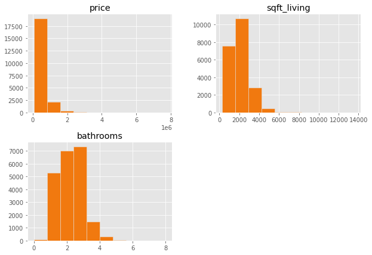

```python
cols=["price","sqft_living","bathrooms"]
plt.style.use('ggplot')
data[cols].hist(figsize=(10, 7),edgecolor='#E6E6E6',color="#F1790F")
plt.show()
```

It seemed that the *price* and the *sqft_living* had the *Skewed Right* distribution.

A summary of the *price*, *sqft_living* and *bathrooms* was obtained.

```python
cols=["price","sqft_living","bathrooms"]
print(data[cols].describe().round())
```

```
           price  sqft_living  bathrooms
count    21613.0      21613.0    21613.0
mean    540088.0       2080.0        2.0
std     367127.0        918.0        1.0
min      75000.0        290.0        0.0
25%     321950.0       1427.0        2.0
50%     450000.0       1910.0        2.0
75%     645000.0       2550.0        2.0
max    7700000.0      13540.0        8.0
```

You can visit the **Appendix** part for more information about the dataset.

**Preprocessing**

The preprocessing operations were applied. The date_time column was created and was split as the year, month, day and year_month. Finally, the data type of *date_year_month* was changed as categorical.

```python
warnings.filterwarnings('ignore')

data['date_time'] = (data['date'].str.split('T'))

for i in range(0,len(data)):
    data['date_time'][i]=pd.to_datetime(data['date_time'][i][0])

data['date_year'] = pd.DatetimeIndex(data['date_time']).year
data['date_month'] = pd.DatetimeIndex(data['date_time']).month
data['date_day'] = pd.DatetimeIndex(data['date_time']).day
data['date_year_month'] = pd.DatetimeIndex(data['date_time']).strftime('%Y-%m')

data['date_year_month']=pd.Categorical(data['date_year_month'])

print(data.iloc[:5,21:])
```

```
             date_time  date_year  date_month  date_day date_year_month
0  2014-10-13 00:00:00       2014          10        13         2014-10
1  2014-12-09 00:00:00       2014          12         9         2014-12
2  2015-02-25 00:00:00       2015           2        25         2015-02
3  2014-12-09 00:00:00       2014          12         9         2014-12
4  2015-02-18 00:00:00       2015           2        18         2015-02
```

**Exploratory Data Analysis**

First of all, the average price by condition and waterfront skill was displayed.

```python
data.pivot_table(index='condition', columns='waterfront',
                    aggfunc={'price':'mean'}).round(2)
```

| waterfront condition | price 0 | price 1 |
| --- | --- | --- |
| 1 | 323274.14 | 658000.00 |
| 2 | 314259.58 | 2555000.00 |
| 3 | 534067.62 | 1759075.82 |
| 4 | 512325.66 | 1520318.00 |
| 5 | 600917.42 | 1579049.60 |

As a result, the average price of a house, which had a water view, was at least twice as expensive as a house, which had not a water view, by each condition.

In this part, the number of sold houses were counted for each year-month.

```python
SET_1=data.groupby('date_year_month')["id"].count()
print(SET_1)
```

```
date_year_month
2014-05    1768
2014-06    2180
2014-07    2211
2014-08    1940
2014-09    1774
2014-10    1878
2014-11    1411
2014-12    1471
2015-01     978
2015-02    1250
2015-03    1875
2015-04    2231
2015-05     646
Name: id, dtype: int64
```

It seemed that 2015-May was not a completed month. To investigate in more detail, the daily number of the sold houses in 2015-May was investigated.

```python
SET_1_2015_day=data[np.logical_and(data["date_year"]==2015,data["date_month"]==5)].groupby('date_day')["id"].count()
print(SET_1_2015_day)
```

```
date_day
1      77
2       6
3      10
4     102
5      94
6      88
7      76
8      54
9       3
10      2
11     40
12     49
13     31
14     11
15      1
24      1
27      1
Name: id, dtype: int64
```

The daily number of the sold houses in 2014-May was obtained on the **Appendix** for benchmarking.

The 2015-May was filtered out to protect the data integrity.

```python
SET_1_2015=data[np.logical_and(data["date_year"]==2015,data["date_month"]!=5)].groupby('date_year_month')["id"].count()
SET_1_2015_V1=SET_1_2015[0:12]
print(SET_1_2015_V1)
```

```
date_year_month
2014-05       0
2014-06       0
2014-07       0
2014-08       0
2014-09       0
2014-10       0
2014-11       0
2014-12       0
2015-01     978
2015-02    1250
2015-03    1875
2015-04    2231
Name: id, dtype: int64
```

```python
SET_1_2014=data[data["date_year"]==2014].groupby('date_year_month')["id"].count()
SET_1_2014_V1=SET_1_2014[0:12]
print(SET_1_2014_V1)
```

```
date_year_month
2014-05    1768
2014-06    2180
2014-07    2211
2014-08    1940
2014-09    1774
2014-10    1878
2014-11    1411
2014-12    1471
2015-01       0
2015-02       0
2015-03       0
2015-04       0
Name: id, dtype: int64
```

The number of sold houses in each month from 2014 to 2015 was shown on a bar chart. The bar chart has been colored on an annual basis for a clear view.

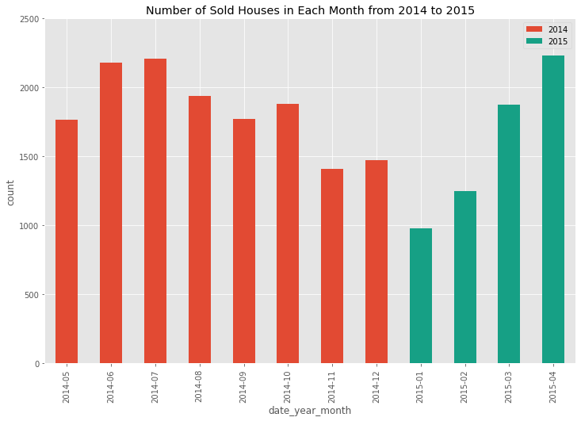

```python
plt.figure(figsize=(12,8), edgecolor='w')
SET_1_2014_V1.plot(kind="bar",title="Number of Sold Houses in Each Month from 2014 to 2015")
plt.ylabel("count")
SET_1_2015_V1.plot(kind="bar",title="Number of Sold Houses in Each Month from 2014 to 2015",color="#16A085")
plt.ylabel("count")
plt.legend(["2014","2015"])
plt.ylim(0,2500)
plt.show()
```

The lowest house sold occurred in January. House sales decrease in winter due to seasonal reasons, such as moving difficulties.

In this part, it was investigated whether there is a relationship between the sqft_living and price. Besides, the grades of the sold houses were presented in the chart.

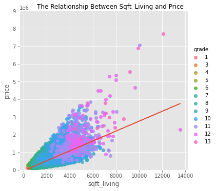

```python
sns.lmplot( x="sqft_living", y="price", data=data, fit_reg=False, hue='grade', legend=True).fig.suptitle("The Relationship Between Sqft_Living and Price")
(s, i) = np.polyfit(data.sqft_living,data.price, 1)
plt.plot(data.sqft_living, s*data.sqft_living+i)
plt.ylim(0,9000000)
plt.show()
```

Additionally, the Pearson correlation coefficient was checked.

```python
r = np.corrcoef(data.sqft_living, data.price)[0,1].round(3)
print(r)
```

```
0.702
```

The Pearson correlation coefficient was 0.70. It showed that there is a positive relationship between sqft_living and price.

Besides, the point, which had the highest sqft_living, was checked.

```python
data.sort_values("sqft_living",ascending=False).head(1)
```

|  | id | date | price | bedrooms | bathrooms | sqft_living | sqft_lot | floors | waterfront | view | condition | grade | sqft_above | sqft_basement | yr_built | yr_renovated | zipcode | lat | long | sqft_living15 | sqft_lot15 | date_time | date_year | date_month | date_day | date_year_month |
| --- | --- | --- | --- | --- | --- | --- | --- | --- | --- | --- | --- | --- | --- | --- | --- | --- | --- | --- | --- | --- | --- | --- | --- | --- | --- | --- |
| 12777 | 1225069038 | 20140505T000000 | 2280000.0 | 7 | 8.0 | 13540 | 307752 | 3.0 | 0 | 4 | 3 | 12 | 9410 | 4130 | 1999 | 0 | 98053 | 47.6675 | -121.986 | 4850 | 217800 | 2014-05-05 00:00:00 | 2014 | 5 | 5 | 2014-05 |

Then, other sold houses, which had high sqft_living and were in the same area as this house, were examined.

```python
data[data["zipcode"]==98053].sort_values("sqft_living",ascending=False).head(5)
```

|  | id | date | price | bedrooms | bathrooms | sqft_living | sqft_lot | floors | waterfront | view | condition | grade | sqft_above | sqft_basement | yr_built | yr_renovated | zipcode | lat | long | sqft_living15 | sqft_lot15 | date_time | date_year | date_month | date_day | date_year_month |
| --- | --- | --- | --- | --- | --- | --- | --- | --- | --- | --- | --- | --- | --- | --- | --- | --- | --- | --- | --- | --- | --- | --- | --- | --- | --- | --- |
| 12777 | 1225069038 | 20140505T000000 | 2280000.0 | 7 | 8.00 | 13540 | 307752 | 3.0 | 0 | 4 | 3 | 12 | 9410 | 4130 | 1999 | 0 | 98053 | 47.6675 | -121.986 | 4850 | 217800 | 2014-05-05 00:00:00 | 2014 | 5 | 5 | 2014-05 |
| 6501 | 2626069030 | 20150209T000000 | 1940000.0 | 4 | 5.75 | 7220 | 223462 | 2.0 | 0 | 4 | 3 | 12 | 6220 | 1000 | 2000 | 0 | 98053 | 47.7097 | -122.013 | 2680 | 7593 | 2015-02-09 00:00:00 | 2015 | 2 | 9 | 2015-02 |
| 5059 | 1125069153 | 20140822T000000 | 1525000.0 | 4 | 3.50 | 5990 | 111078 | 2.0 | 0 | 0 | 3 | 11 | 5990 | 0 | 2004 | 0 | 98053 | 47.6670 | -121.994 | 4690 | 118918 | 2014-08-22 00:00:00 | 2014 | 8 | 22 | 2014-08 |
| 10913 | 2954400310 | 20140915T000000 | 1769000.0 | 4 | 3.50 | 5440 | 38900 | 2.0 | 0 | 0 | 3 | 12 | 5440 | 0 | 1990 | 0 | 98053 | 47.6605 | -122.069 | 4830 | 41313 | 2014-09-15 00:00:00 | 2014 | 9 | 15 | 2014-09 |
| 19564 | 1625069101 | 20140707T000000 | 1360000.0 | 4 | 3.00 | 5430 | 108900 | 2.0 | 0 | 0 | 4 | 10 | 5430 | 0 | 1987 | 0 | 98053 | 47.6582 | -122.038 | 3170 | 107076 | 2014-07-07 00:00:00 | 2014 | 7 | 7 | 2014-07 |

In this part, the average price of sold houses in each zip code was investigated and plotted. To clear view, only 20 zip codes were displayed.

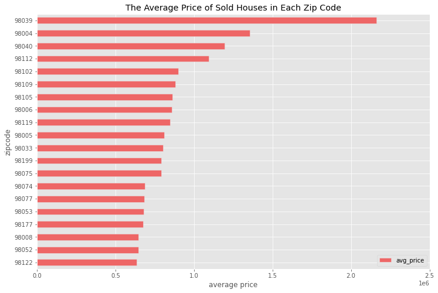

```python
SET_4=data.groupby('zipcode').agg({"price": "mean"})
SET_4=SET_4.sort_values(["price"],ascending=True)
SET_4=SET_4.tail(20)
SET_4.plot(kind="barh",title="The Average Price of Sold Houses in Each Zip Code",color="#EE6666",
           edgecolor='#E6E6E6',figsize=(12, 8), label="avg_price")
plt.xlabel("average price")
plt.xlim(0,2500000)
plt.legend(["avg_price"],loc ="lower right")
plt.show()
```

It seemed that the **98039** had the highest average price than the other zip codes. The **98039** represents Medina. Some billionaires had houses in this area, like Bill Gates and Jeff Bezos.

The sold houses, which had the **98039** zip codes, were shown on the map. The price of the houses was displayed on the popups.

```python
SET_5=data[data["zipcode"]==98039].sort_values("sqft_living",ascending=False)
SET_5_1=SET_5[["price","lat","long"]].sort_values(["price"],ascending=False)
locations=list(zip(SET_5_1.lat, SET_5_1.long))
popup=list(SET_5_1.price)

map = folium.Map(location=[47.63,-122.233],zoom_start=13)
for i in range(len(locations)):
  folium.Marker(location=locations[i], popup ='<i><b>Price: </b></i>'+ str(round(popup[i]))).add_to(map)

map
```

Make this Notebook Trusted to load map: File -> Trust Notebook

[interactive chart not shown]

In this part, the top five houses, which had the highest price, were shown on the map with prices.

```python
SET_3=data[["price","lat","long","zipcode"]].sort_values(["price"],ascending=False).head(5)
locations=list(zip(SET_3.lat, SET_3.long))
popup=list(SET_3.price)

map = folium.Map(location=[47.65,-122.280],zoom_start=12)
for i in range(len(locations)):
  folium.Marker(location=locations[i], popup = '<i><b>Price: </b></i>' + str(round(popup[i]))).add_to(map)

map
```

Make this Notebook Trusted to load map: File -> Trust Notebook

[interactive chart not shown]

The two of them were in Medina. This place had the highest average house price according to the previous analysis. The two of them were in Bellevue, which had the second-highest average house price. One of them was in Capitol Hill. Capitol Hill and Broadway are neighborhoods in Seattle.

Their total floor levels were investigated.

```python
SET_3_2=data[["price","lat","long","floors"]].sort_values(["price"],ascending=False).head(5)
print(SET_3_2)
```

```
          price      lat     long  floors
7252  7700000.0  47.6298 -122.323     2.5
3914  7062500.0  47.6500 -122.214     2.0
9254  6885000.0  47.6305 -122.240     2.0
4411  5570000.0  47.6289 -122.233     2.0
1448  5350000.0  47.6232 -122.220     2.0
```

As a result, all of these houses had more than one floor. The most expensive house had a 2,5-floor level, which was the highest floor level in this subset.

In the final part, the distribution of the zip codes for the sold houses, which had the five conditions, were plotted as a pie chart. To clear view, zip codes, which had more than twenty sold houses, were plotted only.

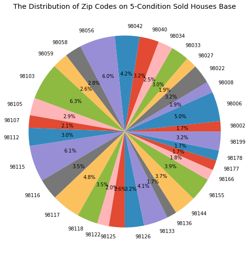

```python
plt.figure(figsize=(13, 9), edgecolor='w')
SET_6=data[data["condition"]==5].groupby('zipcode')["id"].count()
SET_6_2=SET_6[SET_6>20]
SET_6_2.plot.pie(autopct='%1.1f%%')
plt.title("The Distribution of Zip Codes on 5-Condition Sold Houses Base")
plt.ylabel('')
plt.show()
```

The **98103** had the highest amount of five condition sold houses. The **98103** presents Seattle, Washington.

To investigate in more detail, the average sold house prices, which had the five conditions, on zip codes were plotted.

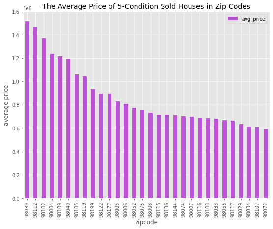

```python
SET_8=data[data["condition"]==5].groupby('zipcode')["price"].mean().sort_values(ascending=False).head(30)
plt.figure(figsize=(9, 7), edgecolor='w')
SET_8.plot(kind="bar",title="The Average Price of 5-Condition Sold Houses in Zip Codes",color="#BA55D3")
plt.ylabel("average price")
plt.ylim(0,1600000)
plt.legend(["avg_price"],loc ="upper right")
plt.show()
```

The condition system has more than one criteria but, it could be due to that there were more affordable five conditions sold houses than other areas.

**Modelling**

In this section, two basic linear regression models were created to predict the price of the houses.

The first model was run with sqft_living and price. As a result of the model, the **Mean Squared Error** and the **R^2** value were calculated.

```python
from sklearn.model_selection import train_test_split
from sklearn.linear_model import LinearRegression
x = data[["sqft_living"]].values
y = data["price"].values

X_train, X_test, y_train, y_test = train_test_split(x, y, test_size=0.2, random_state=0)
lm_1 = LinearRegression()
lm_1.fit(X_train, y_train)
y_pred = lm_1.predict(X_test)

from sklearn import metrics
print('Root Mean Squared Error:', np.sqrt(metrics.mean_squared_error(y_test, y_pred)).round(2))
print('R^2:',lm_1.score(X_train, y_train).round(3))
```

```
Root Mean Squared Error: 248879.06
R^2: 0.496
```

Residuals of the lm_1 model were checked.

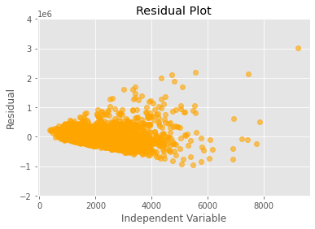

```python
residuals= y_test - y_pred
plt.plot(X_test,residuals,'o',color="orange",alpha=0.6)
plt.title('Residual Plot')
plt.ylabel('Residual')
plt.xlabel('Independent Variable')
plt.ylim(-2000000,4000000)
plt.show()
```

The residuals had not a random distribution.

The second model was run with bathrooms and price. As a result of the model, the **Mean Squared Error** and the **R^2** value were calculated.

```python
x = data[["bathrooms"]].values
y = data["price"].values

X_train, X_test, y_train, y_test = train_test_split(x, y, test_size=0.2, random_state=0)
lm_2 = LinearRegression()
lm_2.fit(X_train, y_train)
y_pred = lm_2.predict(X_test)

from sklearn import metrics
print('Root Mean Squared Error:', np.sqrt(metrics.mean_squared_error(y_test, y_pred)).round(2))
print('R^2:',lm_2.score(X_train, y_train).round(2))
```

```
Root Mean Squared Error: 293733.12
R^2: 0.28
```

Residuals of the lm_2 model were checked.

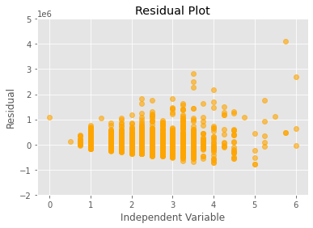

```python
residuals= y_test - y_pred
plt.plot(X_test,residuals,'o',color="orange",alpha=0.6)
plt.title('Residual Plot')
plt.ylabel('Residual')
plt.xlabel('Independent Variable')
plt.ylim(-2000000,5000000)
plt.show()
```

The residuals had a slightly random distribution.

The **Root Mean Squared Error** of the first model was lower than the second model. Additionally, the **R^2** value of the first model was higher than the second model but the **residuals** of the first model **had not a random distribution** so it made the model unreliable.

According to the outputs of the two models, it could be said that the second model (bathrooms, price) gives more reliable results than the first model (sqft_living, price) base on the residual plots.

**Conclusion & Discussion**

- The average price of a house, which had a water view, was at least twice as expensive as a house, which had not a water view, by each condition.
- The lowest house sold occurred in January. House sales decrease in winter due to seasonal reasons.
- It showed that there is a positive relationship between sqft_living and price.
- The Medina had the highest average prices than the other areas. Some billionaires had houses in this area, such as Bill Gates and Jeff Bezos.
- The houses, which had the top five highest price, were shown on the map. All of these houses had more than one floor.
- The 98103 zip code had the highest amount of five condition sold houses. The 98103 presents Seattle, Washington.
- The second model (bathrooms, price) gave more reliable results than the first model (sqft_living, price) base on the residual plots.

In this project, the simple linear regression models were used for prediction. In further analysis, multiple linear regression models were conducted by taking into consideration of colinearity.

**References**

- https://pandas.pydata.org/pandas-docs/stable/reference/api/pandas.to_datetime.html
- https://pandas.pydata.org/pandas-docs/stable/reference/api/pandas.Series.str.split.html
- https://dataplatform.cloud.ibm.com/data/notebooks/converter/assets/79a436d6-51b7-4cb3-962d-5d2bbcb37e78?access_token=025031e1b7902891194b22266aee25230c88c44cfbb55cf3db2e0a7b712c7017&project=87db0240-1cfa-47f3-8b98-396d95cf2671
- https://www.interviewqs.com/ddi-code-snippets/extract-month-year-pandas
- https://www.datasciencearth.com/folium-ile-harita-gorsellestirme/
- https://stackabuse.com/linear-regression-in-python-with-scikit-learn/
- https://www.datasciencearth.com/folium-ile-harita-gorsellestirme/
- https://bingcs.com/2019/12/05/data-analysis-py/
- https://www.kaggle.com/harlfoxem/housesalesprediction
- https://rpubs.com/Mani/report
- https://www.hackdeploy.com/python-linear-regression-analysis/
- https://www.shanelynn.ie/summarising-aggregation-and-grouping-data-in-python-pandas/

**Appendix**

1) The data types of the columns were investigated.

```python
print(data.info())
```

```
<class 'pandas.core.frame.DataFrame'>
RangeIndex: 21613 entries, 0 to 21612
Data columns (total 26 columns):
 #   Column           Non-Null Count  Dtype
---  ------           --------------  -----
 0   id               21613 non-null  int64
 1   date             21613 non-null  object
 2   price            21613 non-null  float64
 3   bedrooms         21613 non-null  int64
 4   bathrooms        21613 non-null  float64
 5   sqft_living      21613 non-null  int64
 6   sqft_lot         21613 non-null  int64
 7   floors           21613 non-null  float64
 8   waterfront       21613 non-null  int64
 9   view             21613 non-null  int64
```

[output cut: 19 more lines]

Besides, it was observed that any column doesn't contain a missing value.

2) The daily number of sold house on 2014-May.

```python
SET_1_2014_day=data[np.logical_and(data["date_year"]==2014,data["date_month"]==5)].groupby('date_day')["id"].count()
print(SET_1_2014_day)
```

```
date_day
2      67
3       4
4       5
5      84
6      83
7      93
8      81
9      81
10      5
11      2
12     80
13     86
14     81
15     82
```

[output cut: 17 more lines]

3) The following line was used to get an HTML output.

```python
!jupyter nbconvert --to html Python_Term_Project_Final.ipynb
```